# machine learning project

Tianyuan Xie

December 27, 2016

1. Backgroud

Using devices such as Jawbone Up, Nike FuelBand, and Fitbit it is now possible to collect a large amount of data about personal activity relatively inexpensively. These type of devices are part of the quantified self movement - a group of enthusiasts who take measurements about themselves regularly to improve their health, to find patterns in their behavior, or because they are tech geeks. One thing that people regularly do is quantify how much of a particular activity they do, but they rarely quantify how well they do it. In this project, your goal will be to use data from accelerometers on the belt, forearm, arm, and dumbell of 6 participants. They were asked to perform barbell lifts correctly and incorrectly in 5 different ways. More information is available from the website here: http://groupware.les.inf.puc-rio.br/har (see the section on the Weight Lifting Exercise Dataset).

2. Load data

```r
library(ggplot2)
library(caret)
library(e1071)
library(randomForest)
setwd('C:/Courses/coursera/08 Machine learning/project')
source('multiplot.R')

url_train <- 'https://d396qusza40orc.cloudfront.net/predmachlearn/pml-training.csv'
url_test <- 'https://d396qusza40orc.cloudfront.net/predmachlearn/pml-testing.csv'
filename_train <- 'train.csv'
filename_test <- 'test.csv'
if(!file.exists(filename_train) & !file.exists(filename_test)) {
        download.file(url_train, filename_train)
        download.file(url_test, filename_test)
}
training <- read.csv(filename_train, na.strings = c('NA', ''))
testing <- read.csv(filename_test, na.strings = c('NA', ''))
```

3. explore data

```r
dim(training)
```

```
## [1] 19622   160
```

```r
head(training)
```

```
##   X user_name raw_timestamp_part_1 raw_timestamp_part_2   cvtd_timestamp
## 1 1  carlitos           1323084231               788290 05/12/2011 11:23
## 2 2  carlitos           1323084231               808298 05/12/2011 11:23
## 3 3  carlitos           1323084231               820366 05/12/2011 11:23
## 4 4  carlitos           1323084232               120339 05/12/2011 11:23
## 5 5  carlitos           1323084232               196328 05/12/2011 11:23
## 6 6  carlitos           1323084232               304277 05/12/2011 11:23
##   new_window num_window roll_belt pitch_belt yaw_belt total_accel_belt
## 1         no         11      1.41       8.07    -94.4                3
## 2         no         11      1.41       8.07    -94.4                3
## 3         no         11      1.42       8.07    -94.4                3
## 4         no         12      1.48       8.05    -94.4                3
## 5         no         12      1.48       8.07    -94.4                3
## 6         no         12      1.45       8.06    -94.4                3
##   kurtosis_roll_belt kurtosis_picth_belt kurtosis_yaw_belt
```

[output cut: 265 more lines]

4. data preprocessing remove missing value

```r
value.column <- apply(training, 2, function(x) sum(is.na(x))/dim(training)[1] < 0.8)
# 100 columns are almost empty so remove them
value.training <- training[, unname(value.column)]
```

The first seven columns are meaningless to model, so remove them as well. do the same thing to testing dataset

```r
value.training <- value.training[,-(1:7)]
value.testing <- testing[, unname(value.column)]
value.testing <- value.testing[, -(1:7)]
```

check if the variables in the training and testing dataset are the same

```r
all.equal(names(value.training)[-53], names(value.testing)[-53])
```

```
## [1] TRUE
```

check zero covariates

```r
nsv <- nearZeroVar(value.training, saveMetrics = T)
nsv
```

```
##                      freqRatio percentUnique zeroVar   nzv
## roll_belt             1.101904     6.7781062   FALSE FALSE
## pitch_belt            1.036082     9.3772296   FALSE FALSE
## yaw_belt              1.058480     9.9734991   FALSE FALSE
## total_accel_belt      1.063160     0.1477933   FALSE FALSE
## gyros_belt_x          1.058651     0.7134849   FALSE FALSE
## gyros_belt_y          1.144000     0.3516461   FALSE FALSE
## gyros_belt_z          1.066214     0.8612782   FALSE FALSE
## accel_belt_x          1.055412     0.8357966   FALSE FALSE
## accel_belt_y          1.113725     0.7287738   FALSE FALSE
## accel_belt_z          1.078767     1.5237998   FALSE FALSE
## magnet_belt_x         1.090141     1.6664968   FALSE FALSE
## magnet_belt_y         1.099688     1.5187035   FALSE FALSE
## magnet_belt_z         1.006369     2.3290184   FALSE FALSE
## roll_arm             52.338462    13.5256345   FALSE FALSE
## pitch_arm            87.256410    15.7323412   FALSE FALSE
## yaw_arm              33.029126    14.6570176   FALSE FALSE
## total_accel_arm       1.024526     0.3363572   FALSE FALSE
## gyros_arm_x           1.015504     3.2769341   FALSE FALSE
## gyros_arm_y           1.454369     1.9162165   FALSE FALSE
## gyros_arm_z           1.110687     1.2638875   FALSE FALSE
## accel_arm_x           1.017341     3.9598410   FALSE FALSE
## accel_arm_y           1.140187     2.7367241   FALSE FALSE
## accel_arm_z           1.128000     4.0362858   FALSE FALSE
## magnet_arm_x          1.000000     6.8239731   FALSE FALSE
## magnet_arm_y          1.056818     4.4439914   FALSE FALSE
## magnet_arm_z          1.036364     6.4468454   FALSE FALSE
## roll_dumbbell         1.022388    84.2065029   FALSE FALSE
## pitch_dumbbell        2.277372    81.7449801   FALSE FALSE
## yaw_dumbbell          1.132231    83.4828254   FALSE FALSE
## total_accel_dumbbell  1.072634     0.2191418   FALSE FALSE
## gyros_dumbbell_x      1.003268     1.2282132   FALSE FALSE
## gyros_dumbbell_y      1.264957     1.4167771   FALSE FALSE
## gyros_dumbbell_z      1.060100     1.0498420   FALSE FALSE
## accel_dumbbell_x      1.018018     2.1659362   FALSE FALSE
## accel_dumbbell_y      1.053061     2.3748853   FALSE FALSE
## accel_dumbbell_z      1.133333     2.0894914   FALSE FALSE
## magnet_dumbbell_x     1.098266     5.7486495   FALSE FALSE
## magnet_dumbbell_y     1.197740     4.3012945   FALSE FALSE
## magnet_dumbbell_z     1.020833     3.4451126   FALSE FALSE
## roll_forearm         11.589286    11.0895933   FALSE FALSE
## pitch_forearm        65.983051    14.8557741   FALSE FALSE
## yaw_forearm          15.322835    10.1467740   FALSE FALSE
## total_accel_forearm   1.128928     0.3567424   FALSE FALSE
## gyros_forearm_x       1.059273     1.5187035   FALSE FALSE
## gyros_forearm_y       1.036554     3.7763735   FALSE FALSE
## gyros_forearm_z       1.122917     1.5645704   FALSE FALSE
## accel_forearm_x       1.126437     4.0464784   FALSE FALSE
## accel_forearm_y       1.059406     5.1116094   FALSE FALSE
## accel_forearm_z       1.006250     2.9558659   FALSE FALSE
## magnet_forearm_x      1.012346     7.7667924   FALSE FALSE
## magnet_forearm_y      1.246914     9.5403119   FALSE FALSE
## magnet_forearm_z      1.000000     8.5771073   FALSE FALSE
## classe                1.469581     0.0254816   FALSE FALSE
```

see the density distribution

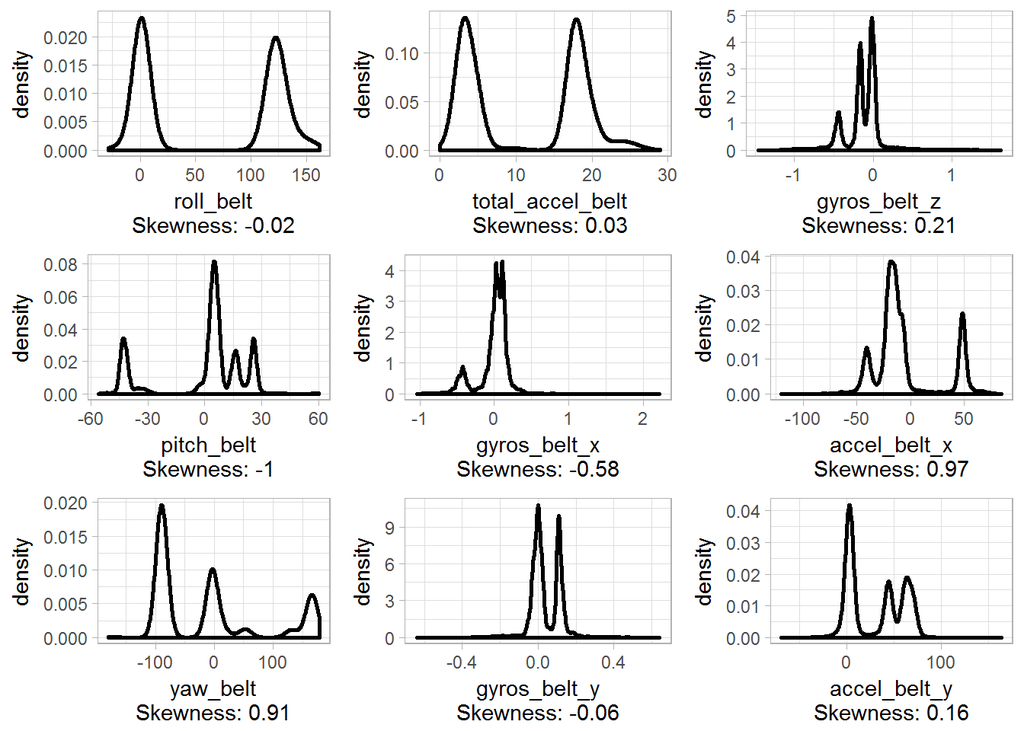

```r
plotDen <- function(data_in, i, lab){
        data <- data.frame(x=data_in[[i]], y=lab)
        p <- ggplot(data= data) + geom_density(aes(x = x), size = 1,alpha = 1.0) +
                xlab(paste0((colnames(data_in)[i]), '\n', 'Skewness: ',round(skewness(data_in[[i]], na.rm = TRUE), 2))) +
                theme_light()
        return(p)
}

pb = list()
for (i in 1:9) {
        pb[[i]] <- plotDen(value.training, i, 'den')
}
# Plot the first nine variables' distribution
multiplot(plotlist = pb, cols = 3)
```

```r
# skewness calculation
#skew <- apply(value.training[,-53], 2, skewness, na.rm = T)
# some variables have very large skewness
#high_skew_name <- names(value.training[,abs(unname(skew)) > 10])
#value.training[, high_skew_name] <- apply(value.training[, high_skew_name], 2, function(x) log10(x-min(x)+1))
```

Split the training data to training and testing dataset

```r
set.seed(1234)
inTrain <- createDataPartition(y = value.training$classe, p = 0.75, list = F)
s.train <- value.training[inTrain,]
s.test <- value.training[-inTrain,]
```

5. model implementation CART

```r
set.seed(1234)
modelfit1 <- train(classe ~ ., method = 'rpart', data = s.train)
pred1 <- predict(modelfit1, s.test)
confusionMatrix(s.test$classe, pred1)
```

```
## Confusion Matrix and Statistics
##
##           Reference
## Prediction    A    B    C    D    E
##          A 1275   28   88    0    4
##          B  390  340  219    0    0
##          C  416   31  408    0    0
##          D  356  141  307    0    0
##          E  134  131  230    0  406
##
## Overall Statistics
##
##                Accuracy : 0.4953
##                  95% CI : (0.4812, 0.5094)
##     No Information Rate : 0.5243
##     P-Value [Acc > NIR] : 1
##
##                   Kappa : 0.3399
##  Mcnemar's Test P-Value : NA
##
## Statistics by Class:
##
##                      Class: A Class: B Class: C Class: D Class: E
## Sensitivity            0.4959  0.50671   0.3259       NA  0.99024
## Specificity            0.9486  0.85613   0.8776   0.8361  0.88985
## Pos Pred Value         0.9140  0.35827   0.4772       NA  0.45061
## Neg Pred Value         0.6307  0.91631   0.7916       NA  0.99900
## Prevalence             0.5243  0.13683   0.2553   0.0000  0.08361
## Detection Rate         0.2600  0.06933   0.0832   0.0000  0.08279
## Detection Prevalence   0.2845  0.19352   0.1743   0.1639  0.18373
## Balanced Accuracy      0.7222  0.68142   0.6017       NA  0.94005
```

The model accuracy is around 50%, which is not acceptable.

Random Forest

```r
modelfit2 <- randomForest(classe ~ .,data = s.train, trControl=trainControl(method = "cv", number = 4))
pred2 <- predict(modelfit2, s.test)
confusionMatrix(s.test$classe, pred2)
```

```
## Confusion Matrix and Statistics
##
##           Reference
## Prediction    A    B    C    D    E
##          A 1395    0    0    0    0
##          B    3  944    2    0    0
##          C    0    9  845    1    0
##          D    0    0    6  798    0
##          E    0    0    0    0  901
##
## Overall Statistics
##
##                Accuracy : 0.9957
##                  95% CI : (0.9935, 0.9973)
##     No Information Rate : 0.2851
##     P-Value [Acc > NIR] : < 2.2e-16
##
##                   Kappa : 0.9946
##  Mcnemar's Test P-Value : NA
##
## Statistics by Class:
##
##                      Class: A Class: B Class: C Class: D Class: E
## Sensitivity            0.9979   0.9906   0.9906   0.9987   1.0000
## Specificity            1.0000   0.9987   0.9975   0.9985   1.0000
## Pos Pred Value         1.0000   0.9947   0.9883   0.9925   1.0000
## Neg Pred Value         0.9991   0.9977   0.9980   0.9998   1.0000
## Prevalence             0.2851   0.1943   0.1739   0.1629   0.1837
## Detection Rate         0.2845   0.1925   0.1723   0.1627   0.1837
## Detection Prevalence   0.2845   0.1935   0.1743   0.1639   0.1837
## Balanced Accuracy      0.9989   0.9946   0.9941   0.9986   1.0000
```

The random forest model shows 99% accurcy in data classification. So this algorithm is chosen to predict the class in the testing dataset.

6. Testing dataset prediction

```r
predict(modelfit2, value.testing)
```

```
##  1  2  3  4  5  6  7  8  9 10 11 12 13 14 15 16 17 18 19 20
##  B  A  B  A  A  E  D  B  A  A  B  C  B  A  E  E  A  B  B  B
## Levels: A B C D E
```